# Costo del retraso en la disponibilidad de datos ambientales — Racafé

Informe reproducible (OE4)

> **Aviso.** Las cifras de este informe se calculan sobre mediciones y lotes **sintéticos** (etiqueta: SINTETICO). Demuestran que el método funciona de punta a punta; **no son hallazgos sobre Racafé**. Con datos reales el mismo código se ejecuta en local (ver README) y sus salidas no se publican.

## OE1. Frecuencia y duración de alarmas

| Lecturas | Bodegas | % alarma amplia | % evento crítico | Episodios críticos |
| --- | --- | --- | --- | --- |
| 133632 | 24 | 84 | 29 | 3051 |

Con la definición amplia (cualquier lectura fuera de la zona segura) casi todas las horas son “alarma” y no hay eventos separables; por eso el modelo usa **eventos críticos** (GPP saturado, temperatura alta o riesgo de condensación).

| sede_codigo | n_lecturas | pct_alarma_amplia | pct_riesgo_humedad | pct_temp_alta | pct_condensacion | pct_evento_critico |
| --- | --- | --- | --- | --- | --- | --- |
| RA | 16704 | 79.4 | 80.8 | 3.5 | 0.0 | 16.0 |
| RAA | 16704 | 84.7 | 91.1 | 3.6 | 0.4 | 24.2 |
| RB | 16704 | 98.5 | 98.7 | 24.7 | 0.0 | 49.5 |
| RH | 16704 | 92.8 | 93.5 | 12.2 | 0.0 | 36.6 |
| RM | 16704 | 56.5 | 57.1 | 1.6 | 0.0 | 2.3 |
| RP | 16704 | 65.2 | 65.7 | 4.6 | 0.0 | 6.3 |
| RS | 16704 | 97.7 | 97.8 | 24.0 | 0.0 | 54.4 |
| RY | 16704 | 96.9 | 96.9 | 24.8 | 0.0 | 42.7 |

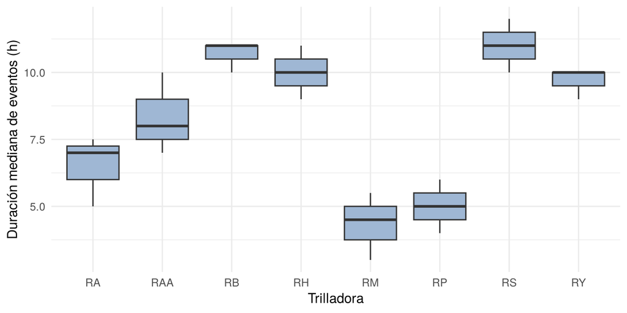

Ajuste de la duración (menor AIC es mejor):

| modelo | aic | par1 | par2 |
| --- | --- | --- | --- |
| lognormal | 21110.10 | 1.92 | 1.13 |
| gamma | 21605.87 | 0.93 | 0.07 |

## OE2. Severidad y pérdida agregada (esquema semanal)

Severidad: `pct_rebaja = min(0.25, k · horas sin corregir)`, con k = 0.000502 (R² = 0.96, n = 397 lotes con exposición).

## OE3. Comparación de esquemas de actualización

| Esquema | Media (M COP) | VaR 95% (M COP) | CVaR 95% (M COP) | IC95% CVaR (M COP) | Reducción CVaR (%) |
| --- | --- | --- | --- | --- | --- |
| semanal | 1.249 | 1.304 | 1.317 | 1.315 – 1.318 | 0.0 |
| diaria | 852 | 880 | 887 | 886 – 888 | 32.6 |
| tiempo_real | 465 | 479 | 482 | 482 – 482 | 63.4 |

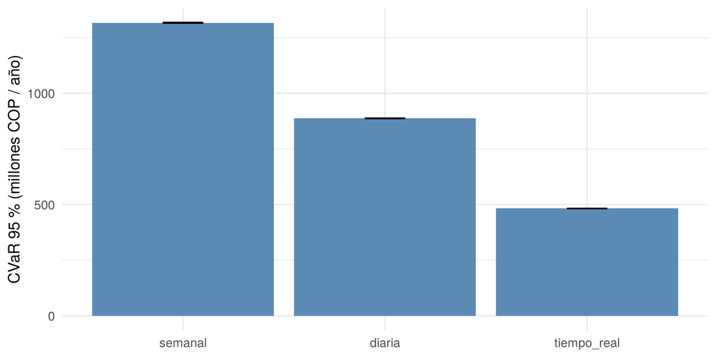

### Sensibilidad a supuestos

| beta | respuesta (h) | esquema | Reducción CVaR (%) |
| --- | --- | --- | --- |
| 1.0 | 1 | diaria | 36.9 |
| 1.0 | 1 | tiempo_real | 83.1 |
| 1.0 | 4 | diaria | 32.5 |
| 1.0 | 4 | tiempo_real | 63.4 |
| 1.0 | 12 | diaria | 21.4 |
| 1.0 | 12 | tiempo_real | 29.9 |
| 1.3 | 1 | diaria | 49.9 |
| 1.3 | 1 | tiempo_real | 91.8 |
| 1.3 | 4 | diaria | 46.1 |
| 1.3 | 4 | tiempo_real | 77.1 |
| 1.3 | 12 | diaria | 34.1 |
| 1.3 | 12 | tiempo_real | 44.8 |

### Escenarios de severidad

Tres escenarios que cambian solo supuestos (ver `R/escenarios.R`): **optimista** (rebaja por hora a la mitad, tope 15 %, respuesta en 1 h), **base** y **pesimista** (rebaja 1,5 veces, respuesta en 12 h).

| escenario | esquema | Media (M COP) | CVaR 95 % (M COP) | Reducción CVaR (%) |
| --- | --- | --- | --- | --- |
| optimista | semanal | 616 | 649 | 0.0 |
| optimista | diaria | 393 | 410 | 36.9 |
| optimista | tiempo_real | 106 | 110 | 83.1 |
| base | semanal | 1.248 | 1.315 | 0.0 |
| base | diaria | 852 | 887 | 32.5 |
| base | tiempo_real | 465 | 482 | 63.4 |
| pesimista | semanal | 1.936 | 2.041 | 0.0 |
| pesimista | diaria | 1.540 | 1.604 | 21.4 |
| pesimista | tiempo_real | 1.377 | 1.430 | 29.9 |

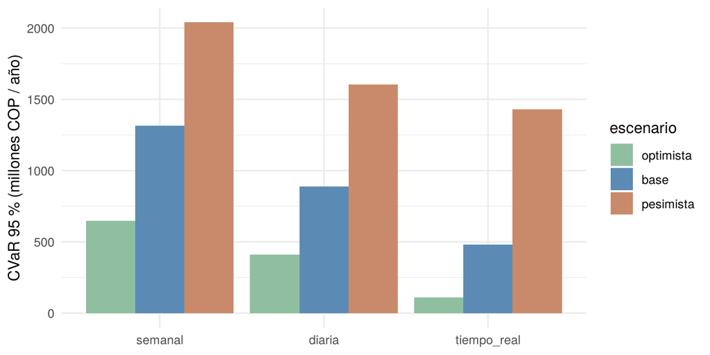

La conclusión cualitativa (menos latencia ⇒ menos riesgo de cola) se sostiene en todos los supuestos; la **magnitud** depende del tiempo de respuesta y de la forma de la severidad, que solo los datos reales de rebajas pueden fijar.

## Supuestos

Ver `README.md` y `R/00_config.R`. Cada supuesto está en un solo lugar y es editable.